# Fadel Alshammasi & Yahan Chang

# Final project: Indian food analysis & classification prediction

```python
import pandas as pd
import numpy as np
import matplotlib as mpt
import matplotlib.pyplot as plt
import seaborn as sns
import statsmodels.api as sm
from bokeh.models import ColumnDataSource
from bokeh.io import output_notebook,output_file, show
from bokeh.io import output_notebook, show
from bokeh.plotting import figure
from bokeh.models import ColumnDataSource, CDSView, GroupFilter
import plotly.express as px
import plotly.graph_objects as go
import collections
```

```python
df=pd.read_csv('indian_food.csv')
```

```python
df
```

|  | name | ingredients | diet | prep_time | cook_time | flavor_profile | course | state | region |
| --- | --- | --- | --- | --- | --- | --- | --- | --- | --- |
| 0 | Balu shahi | Maida flour, yogurt, oil, sugar | vegetarian | 45 | 25 | sweet | dessert | West Bengal | East |
| 1 | Boondi | Gram flour, ghee, sugar | vegetarian | 80 | 30 | sweet | dessert | Rajasthan | West |
| 2 | Gajar ka halwa | Carrots, milk, sugar, ghee, cashews, raisins | vegetarian | 15 | 60 | sweet | dessert | Punjab | North |
| 3 | Ghevar | Flour, ghee, kewra, milk, clarified butter, su... | vegetarian | 15 | 30 | sweet | dessert | Rajasthan | West |
| 4 | Gulab jamun | Milk powder, plain flour, baking powder, ghee,... | vegetarian | 15 | 40 | sweet | dessert | West Bengal | East |
| ... | ... | ... | ... | ... | ... | ... | ... | ... | ... |
| 250 | Til Pitha | Glutinous rice, black sesame seeds, gur | vegetarian | 5 | 30 | sweet | dessert | Assam | North East |
| 251 | Bebinca | Coconut milk, egg yolks, clarified butter, all... | vegetarian | 20 | 60 | sweet | dessert | Goa | West |
| 252 | Shufta | Cottage cheese, dry dates, dried rose petals, ... | vegetarian | -1 | -1 | sweet | dessert | Jammu & Kashmir | North |
| 253 | Mawa Bati | Milk powder, dry fruits, arrowroot powder, all... | vegetarian | 20 | 45 | sweet | dessert | Madhya Pradesh | Central |
| 254 | Pinaca | Brown rice, fennel seeds, grated coconut, blac... | vegetarian | -1 | -1 | sweet | dessert | Goa | West |

255 rows × 9 columns

```python
df.isna().any()
```

```
name              False
ingredients       False
diet              False
prep_time         False
cook_time         False
flavor_profile    False
course            False
state             False
region             True
dtype: bool
```

```python
df.isna().sum()
```

```
name              0
ingredients       0
diet              0
prep_time         0
cook_time         0
flavor_profile    0
course            0
state             0
region            1
dtype: int64
```

```python
df=df.replace(to_replace = np.nan, value = -1)
```

```python
df = df.replace(['-1'],'Unkown')
df = df.replace([-1],'Unkown')
```

```python
df.prep_time
```

```
0          45
1          80
2          15
3          15
4          15
        ...
250         5
251        20
252    Unkown
253        20
254    Unkown
Name: prep_time, Length: 255, dtype: object
```

```python
df=df[(df.ingredients != 'Unkown') & (df.diet != 'Unkown') & (df.prep_time != 'Unkown') & (df.cook_time != 'Unkown') & (df.flavor_profile != 'Unkown') & (df.course != 'Unkown')& (df.state != 'Unkown')& (df.region != "Unkown")]
```

```python
df = df.reset_index(drop=True)
```

```python
df
```

|  | name | ingredients | diet | prep_time | cook_time | flavor_profile | course | state | region |
| --- | --- | --- | --- | --- | --- | --- | --- | --- | --- |
| 0 | Balu shahi | Maida flour, yogurt, oil, sugar | vegetarian | 45 | 25 | sweet | dessert | West Bengal | East |
| 1 | Boondi | Gram flour, ghee, sugar | vegetarian | 80 | 30 | sweet | dessert | Rajasthan | West |
| 2 | Gajar ka halwa | Carrots, milk, sugar, ghee, cashews, raisins | vegetarian | 15 | 60 | sweet | dessert | Punjab | North |
| 3 | Ghevar | Flour, ghee, kewra, milk, clarified butter, su... | vegetarian | 15 | 30 | sweet | dessert | Rajasthan | West |
| 4 | Gulab jamun | Milk powder, plain flour, baking powder, ghee,... | vegetarian | 15 | 40 | sweet | dessert | West Bengal | East |
| ... | ... | ... | ... | ... | ... | ... | ... | ... | ... |
| 175 | Prawn malai curry | Coconut milk, prawns, garlic, turmeric, sugar | non vegetarian | 15 | 50 | spicy | main course | West Bengal | East |
| 176 | Shukto | Green beans, bitter gourd, ridge gourd, banana... | vegetarian | 10 | 20 | spicy | main course | West Bengal | East |
| 177 | Til Pitha | Glutinous rice, black sesame seeds, gur | vegetarian | 5 | 30 | sweet | dessert | Assam | North East |
| 178 | Bebinca | Coconut milk, egg yolks, clarified butter, all... | vegetarian | 20 | 60 | sweet | dessert | Goa | West |
| 179 | Mawa Bati | Milk powder, dry fruits, arrowroot powder, all... | vegetarian | 20 | 45 | sweet | dessert | Madhya Pradesh | Central |

180 rows × 9 columns

```python
# adding a new column total_time
sum_time = df["prep_time"] + df["cook_time"]
df["total_time"] = sum_time
```

```python
df
```

|  | name | ingredients | diet | prep_time | cook_time | flavor_profile | course | state | region | total_time |
| --- | --- | --- | --- | --- | --- | --- | --- | --- | --- | --- |
| 0 | Balu shahi | Maida flour, yogurt, oil, sugar | vegetarian | 45 | 25 | sweet | dessert | West Bengal | East | 70 |
| 1 | Boondi | Gram flour, ghee, sugar | vegetarian | 80 | 30 | sweet | dessert | Rajasthan | West | 110 |
| 2 | Gajar ka halwa | Carrots, milk, sugar, ghee, cashews, raisins | vegetarian | 15 | 60 | sweet | dessert | Punjab | North | 75 |
| 3 | Ghevar | Flour, ghee, kewra, milk, clarified butter, su... | vegetarian | 15 | 30 | sweet | dessert | Rajasthan | West | 45 |
| 4 | Gulab jamun | Milk powder, plain flour, baking powder, ghee,... | vegetarian | 15 | 40 | sweet | dessert | West Bengal | East | 55 |
| ... | ... | ... | ... | ... | ... | ... | ... | ... | ... | ... |
| 175 | Prawn malai curry | Coconut milk, prawns, garlic, turmeric, sugar | non vegetarian | 15 | 50 | spicy | main course | West Bengal | East | 65 |
| 176 | Shukto | Green beans, bitter gourd, ridge gourd, banana... | vegetarian | 10 | 20 | spicy | main course | West Bengal | East | 30 |
| 177 | Til Pitha | Glutinous rice, black sesame seeds, gur | vegetarian | 5 | 30 | sweet | dessert | Assam | North East | 35 |
| 178 | Bebinca | Coconut milk, egg yolks, clarified butter, all... | vegetarian | 20 | 60 | sweet | dessert | Goa | West | 80 |
| 179 | Mawa Bati | Milk powder, dry fruits, arrowroot powder, all... | vegetarian | 20 | 45 | sweet | dessert | Madhya Pradesh | Central | 65 |

180 rows × 10 columns

```python
df['diet'].value_counts()
```

```
vegetarian        163
non vegetarian     17
Name: diet, dtype: int64
```

```python
# Analysis 1: vegetarian vs. non-vegetarian pie chart
pie_chart = df['diet'].value_counts().reset_index()
pie_chart.columns = ['diet','count']
fig = px.pie(pie_chart,  title='Proportion of vegetarian vs. non-vegetarian Indian dishes', values='count', names='diet')
fig.show()
```

[interactive chart not shown]

## The overwhelming majority of Indian food recipes are vegetarian!

```python
# make diet column a numerical variable
df = df.replace(['vegetarian'],1) # vegetarian= 1
df = df.replace(['non vegetarian'],0) # non-vegetarian= 0
```

```python
df
```

|  | name | ingredients | diet | prep_time | cook_time | flavor_profile | course | state | region | total_time |
| --- | --- | --- | --- | --- | --- | --- | --- | --- | --- | --- |
| 0 | Balu shahi | Maida flour, yogurt, oil, sugar | 1 | 45 | 25 | sweet | dessert | West Bengal | East | 70 |
| 1 | Boondi | Gram flour, ghee, sugar | 1 | 80 | 30 | sweet | dessert | Rajasthan | West | 110 |
| 2 | Gajar ka halwa | Carrots, milk, sugar, ghee, cashews, raisins | 1 | 15 | 60 | sweet | dessert | Punjab | North | 75 |
| 3 | Ghevar | Flour, ghee, kewra, milk, clarified butter, su... | 1 | 15 | 30 | sweet | dessert | Rajasthan | West | 45 |
| 4 | Gulab jamun | Milk powder, plain flour, baking powder, ghee,... | 1 | 15 | 40 | sweet | dessert | West Bengal | East | 55 |
| ... | ... | ... | ... | ... | ... | ... | ... | ... | ... | ... |
| 175 | Prawn malai curry | Coconut milk, prawns, garlic, turmeric, sugar | 0 | 15 | 50 | spicy | main course | West Bengal | East | 65 |
| 176 | Shukto | Green beans, bitter gourd, ridge gourd, banana... | 1 | 10 | 20 | spicy | main course | West Bengal | East | 30 |
| 177 | Til Pitha | Glutinous rice, black sesame seeds, gur | 1 | 5 | 30 | sweet | dessert | Assam | North East | 35 |
| 178 | Bebinca | Coconut milk, egg yolks, clarified butter, all... | 1 | 20 | 60 | sweet | dessert | Goa | West | 80 |
| 179 | Mawa Bati | Milk powder, dry fruits, arrowroot powder, all... | 1 | 20 | 45 | sweet | dessert | Madhya Pradesh | Central | 65 |

180 rows × 10 columns

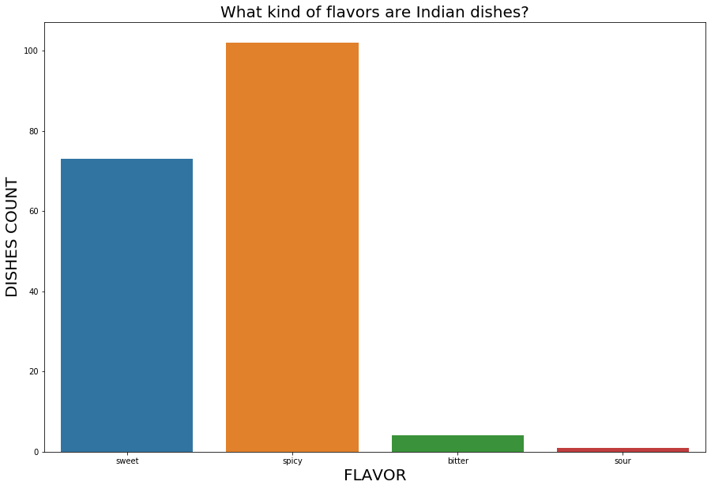

```python
#Analysis 2: flavors count
plt.figure(figsize=(15,10))
plt.title("What kind of flavors are Indian dishes?",fontsize=20)
p=sns.countplot(df['flavor_profile'])
p.set_xlabel("FLAVOR", fontsize=20)
p.set_ylabel("DISHES COUNT", fontsize=20)
```

## Indians prefer eating spicy food as opposed to other types of flavor that are not that popular in India such as bitter and sour. It looks like sweets are also popular in India.

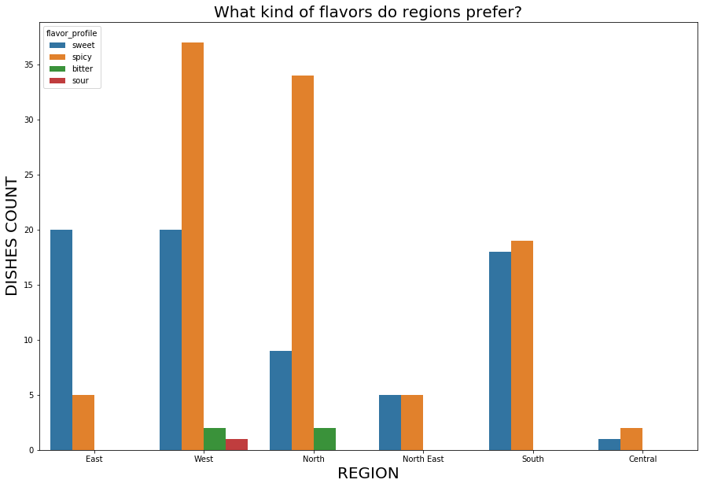

```python
#Analysis 3 flavors count by region
plt.figure(figsize=(15,10))
plt.title("What kind of flavors do regions prefer?", fontsize=20)
p=sns.countplot(data=df, x="region",hue="flavor_profile");
p.set_xlabel("REGION", fontsize=20)
p.set_ylabel("DISHES COUNT", fontsize=20)
```

## East Region is the only region that has more dishes that are not spicy.

```python
#Analysis 4: Dishes per state by showing an interactive map of the Indian States
# Credit to: https://stackoverflow.com/questions/60910962/is-there-any-way-to-draw-india-map-in-plotly

df4=df.groupby('state')['name'].count().reset_index()
df4.columns=['state','count']
fig = go.Figure(data=go.Choropleth(
    geojson="https://gist.githubusercontent.com/jbrobst/56c13bbbf9d97d187fea01ca62ea5112/raw/e388c4cae20aa53cb5090210a42ebb9b765c0a36/india_states.geojson",
    featureidkey='properties.ST_NM',
    locationmode='geojson-id',
    locations=df4['state'],
    z=df4['count'],
    autocolorscale=False,
    colorscale='Reds',
    marker_line_color='peachpuff',
    colorbar=dict(
        title={'text': " # Dishes per State"},

        thickness=20,
        len=0.4,
        bgcolor='rgba(255,255,255,0.6)',

        tick0=0,
        dtick=5,

        xanchor='right',
        x=1.2,
        yanchor='bottom',
        y=0.2
    )
))

fig.update_geos(
    visible=False,
    resolution=110,
    projection=dict(
        type='conic conformal',
        parallels=[12.472944444, 35.172805555556],
        rotation={'lat': 24, 'lon': 80}
    ),

    lonaxis={'range': [68, 98]},
    lataxis={'range': [6, 38]}
)

fig.update_layout(
    title=dict(
        text="Number of Dishes per State",
        xanchor='center',
        x=0.5,
        yref='paper',
        yanchor='bottom',
        y=0.85,
        pad={'b': 10}
    ),
    margin={'r': 0, 't': 20, 'l': 0, 'b': 0},
    height=750,
    width=750
)


fig.show()
```

[interactive chart not shown]

## Panjab is the home of most Indian dishes with 30 dishes (beating Gujarat by only 1)!

```python
#Analysis 5 Dishes by region
import plotly.graph_objects as go
fig = go.Figure()
fig.add_trace(go.Histogram(x = df['region'], marker_color='purple'))

fig.update_layout(title_text='Number of Indian Dishes by Region',xaxis_title_text='REGION',yaxis_title_text='COUNT')

fig.show()
```

[interactive chart not shown]

## The West region is the region where most of Indian dishes come from.

```python
# Adding a new column to count how many ingredients there are for each dish
ing = []
ing_set=set(ing)
ing=[]
df['ingredients_count']="TBD"
for ind in df.index:
    col=df["ingredients"]
    s=col[ind]
    df.at[ind,'ingredients_count']=len(s.split(","))
    ing+=s.split(",")
```

```python
ing_set=set(ing)
```

```python
#Analysis 6 Unique # of ingredients
print("There are" , len(ing_set), "unique ingredients.")
```

```
There are 326 unique ingredients.
```

```python
# Most common ingredients with their count
ing_count = collections.Counter(ing)
print(ing_count.most_common())
```

```
[(' sugar', 33), (' garam masala', 23), (' ghee', 21), (' ginger', 18), (' jaggery', 17), ('Rice flour', 15), (' curry leaves', 13), (' milk', 11), (' garam masala powder', 11), (' urad dal', 11), (' saffron', 9), (' turmeric', 9), (' coconut', 9), (' sesame seeds', 9), (' tomato', 8), (' gram flour…
```

```python
df2=df.copy()
df2['ingredient']="TBD"
df2['ingredient_count']="TBD"
i=0
for key in ing_count:
        df2.at[i,'ingredient']=key
        df2.at[i,'ingredient_count']=ing_count[key]
        i+=1
```

```python
#Analysis 7: Most common ingredients with their count + percentages of the total number of ingredients
df3 = pd.DataFrame(ing, columns = ['ingred'])

pie_chart = df3['ingred'].value_counts().reset_index()
pie_chart.columns = ['ingredient','count']
fig = px.pie(pie_chart,  title='Counting the appearance of each individual ingredient ', values='count', names='ingredient')
fig.show()
```

[interactive chart not shown]

## As you can see, sugar is the most frequent ingredient that is used in Indian dishes followed by garam masala with just under 3%.

```python
df["ingredients_count"] = df["ingredients_count"].astype(str).astype(int)
```

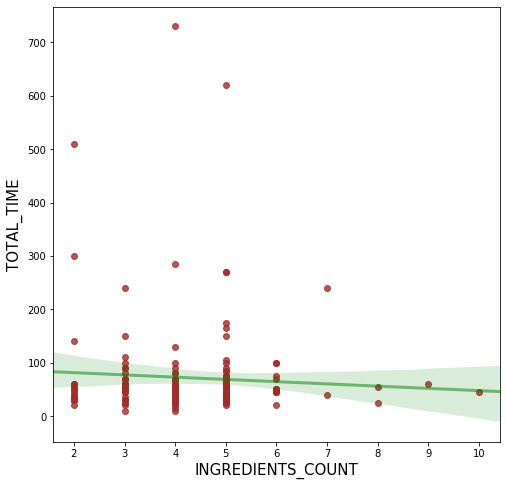

```python
#Analysis 8 scatter plot to check if the total time (prepare+ cook) has anything to do with the number of ingredients for each dish
plt.figure(figsize=(8,8))

p=sns.regplot(data=df, x="ingredients_count", y="total_time", color='brown', line_kws={"color":"g","alpha":0.5,"lw":3})
p.set_xlabel("INGREDIENTS_COUNT", fontsize=15)
p.set_ylabel("TOTAL_TIME", fontsize=15)
```

## There's a weak negative correlation between the number of ingredients and the total time! This is quite shocking because we expcted to see a strong positive correlation.

```python
df.describe()
```

|  | diet | prep_time | cook_time | total_time | ingredients_count |
| --- | --- | --- | --- | --- | --- |
| count | 180.000000 | 180.000000 | 180.000000 | 180.000000 | 180.000000 |
| mean | 0.905556 | 30.705556 | 40.366667 | 71.072222 | 4.427778 |
| std | 0.293262 | 64.158036 | 54.377215 | 86.334353 | 1.307608 |
| min | 0.000000 | 5.000000 | 5.000000 | 10.000000 | 2.000000 |
| 25% | 1.000000 | 10.000000 | 25.000000 | 40.000000 | 4.000000 |
| 50% | 1.000000 | 10.000000 | 30.000000 | 50.000000 | 5.000000 |
| 75% | 1.000000 | 20.000000 | 45.000000 | 70.000000 | 5.000000 |
| max | 1.000000 | 500.000000 | 720.000000 | 730.000000 | 10.000000 |

```python
from sklearn.preprocessing import LabelEncoder
from sklearn.preprocessing import OneHotEncoder




#columns that need one hot encoding
cols = ['flavor_profile', 'course', 'state', 'region']
df_ = df[cols]
enc_cols = df_.apply(LabelEncoder().fit_transform)
yahan = df[['diet','ingredients_count', 'prep_time', 'cook_time','total_time']]
#combine with other number columns
df_w_enc = pd.concat([yahan, enc_cols], axis = 1)
df_w_enc.head()

df_w_enc
```

|  | diet | ingredients_count | prep_time | cook_time | total_time | flavor_profile | course | state | region |
| --- | --- | --- | --- | --- | --- | --- | --- | --- | --- |
| 0 | 1 | 4 | 45 | 25 | 70 | 3 | 0 | 22 | 1 |
| 1 | 1 | 3 | 80 | 30 | 110 | 3 | 0 | 17 | 5 |
| 2 | 1 | 6 | 15 | 60 | 75 | 3 | 0 | 16 | 2 |
| 3 | 1 | 10 | 15 | 30 | 45 | 3 | 0 | 17 | 5 |
| 4 | 1 | 8 | 15 | 40 | 55 | 3 | 0 | 22 | 1 |
| ... | ... | ... | ... | ... | ... | ... | ... | ... | ... |
| 175 | 0 | 5 | 15 | 50 | 65 | 2 | 1 | 22 | 1 |
| 176 | 1 | 5 | 10 | 20 | 30 | 2 | 1 | 22 | 1 |
| 177 | 1 | 3 | 5 | 30 | 35 | 3 | 0 | 1 | 3 |
| 178 | 1 | 4 | 20 | 60 | 80 | 3 | 0 | 4 | 5 |
| 179 | 1 | 4 | 20 | 45 | 65 | 3 | 0 | 10 | 0 |

180 rows × 9 columns

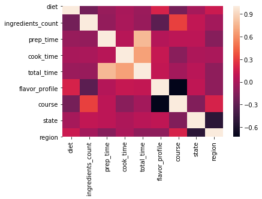

```python
#Analysis 9: corelation table (that includes state, region,course, flavor, and diet because we encoded them)
df_w_enc.corr()
indianfood_ctable = df_w_enc.corr(method = 'pearson')
indianfood_ctable
indianfood_hmap = sns.heatmap(indianfood_ctable)
```

# HeatMap for corelation

```python
indianfood_ctable
```

|  | diet | ingredients_count | prep_time | cook_time | total_time | flavor_profile | course | state | region |
| --- | --- | --- | --- | --- | --- | --- | --- | --- | --- |
| diet | 1.000000 | -0.214561 | -0.073638 | -0.008326 | -0.059967 | 0.187865 | -0.207317 | -0.014626 | 0.134737 |
| ingredients_count | -0.214561 | 1.000000 | -0.084393 | -0.001747 | -0.063816 | -0.316309 | 0.316217 | 0.094876 | -0.023811 |
| prep_time | -0.073638 | -0.084393 | 1.000000 | 0.054531 | 0.777480 | 0.041462 | 0.074264 | 0.072684 | -0.138972 |
| cook_time | -0.008326 | -0.001747 | 0.054531 | 1.000000 | 0.670368 | 0.111725 | -0.129100 | 0.015127 | -0.002472 |
| total_time | -0.059967 | -0.063816 | 0.777480 | 0.670368 | 1.000000 | 0.101181 | -0.026125 | 0.063541 | -0.104831 |
| flavor_profile | 0.187865 | -0.316309 | 0.041462 | 0.111725 | 0.101181 | 1.000000 | -0.723556 | 0.085295 | -0.110386 |
| course | -0.207317 | 0.316217 | 0.074264 | -0.129100 | -0.026125 | -0.723556 | 1.000000 | -0.164347 | 0.188967 |
| state | -0.014626 | 0.094876 | 0.072684 | 0.015127 | 0.063541 | 0.085295 | -0.164347 | 1.000000 | -0.526487 |
| region | 0.134737 | -0.023811 | -0.138972 | -0.002472 | -0.104831 | -0.110386 | 0.188967 | -0.526487 | 1.000000 |